# Tarea3

Julius Döbelt

03 9 2022

Librerías

```r
library("stats")
library("psych")
library("readxl")
library("MASS")
library("ISLR")
library("fRegression")
library("vcd")
library("dplyr")
library("openxlsx")
```

1 a)

```r
setwd("C:/Users/User/Documents/Tec de Monterrey/Analysis de Datos/Tarea3")
base <- read.csv("BaseActividad3.csv")
str(base)
```

```
## 'data.frame':    1930180 obs. of  12 variables:
##  $ X             : int  1 2 3 4 5 6 7 8 9 10 ...
##  $ step          : int  1 1 1 1 1 1 1 1 1 1 ...
##  $ type          : chr  "PAYMENT" "PAYMENT" "TRANSFER" "CASH_OUT" ...
##  $ amount        : num  9840 1864 181 181 11668 ...
##  $ nameOrig      : chr  "C1231006815" "C1666544295" "C1305486145" "C840083671" ...
##  $ oldbalanceOrg : num  170136 21249 181 181 41554 ...
##  $ newbalanceOrig: num  160296 19385 0 0 29886 ...
##  $ nameDest      : chr  "M1979787155" "M2044282225" "C553264065" "C38997010" ...
##  $ oldbalanceDest: num  0 0 0 21182 0 ...
##  $ newbalanceDest: num  0 0 0 0 0 ...
##  $ isFraud       : int  0 0 1 1 0 0 0 0 0 0 ...
##  $ isFlaggedFraud: int  0 0 0 0 0 0 0 0 0 0 ...
```

Una base de datos más pequeno porque no tengo un computador poderoso.

```r
set.seed(123)
index_sample <- sample(1:length(base$isFraud), 10000)
stripped_data <- base[index_sample,]
```

```r
base[!complete.cases(base),]
```

```
##  [1] X              step           type           amount         nameOrig
##  [6] oldbalanceOrg  newbalanceOrig nameDest       oldbalanceDest newbalanceDest
## [11] isFraud        isFlaggedFraud
## <0 Zeilen> (oder row.names mit Länge 0)
```

No hay NA’s en la gran base de datos, qué es bueno!

3. No es necesario de estandizar variables.
4. Creo dummy variables para la columna “type”, porque es una variable categorial y necesitolo para la análisis.

Para la gran base de datos:

```r
base$type_payment <- ifelse(base$type=="PAYMENT",1,0)
base$type_transfer <- ifelse(base$type=="TRANSFER",1,0)
base$type_cashout <- ifelse(base$type=="CASH_OUT",1,0)
base$type_cashin <- ifelse(base$type=="CASH_IN",1,0)
base$type_debit <- ifelse(base$type=="DEBIT",1,0)
```

Para la base de datos pequeno:

```r
stripped_data$type_payment <- ifelse(stripped_data$type=="PAYMENT",1,0)
stripped_data$type_transfer <- ifelse(stripped_data$type=="TRANSFER",1,0)
stripped_data$type_cashout <- ifelse(stripped_data$type=="CASH_OUT",1,0)
stripped_data$type_cashin <- ifelse(stripped_data$type=="CASH_IN",1,0)
stripped_data$type_debit <- ifelse(stripped_data$type=="DEBIT",1,0)
```

Seleciono las columnas qué necesito para la modelación.

```r
new_base <- select(base, step, amount, oldbalanceOrg, newbalanceOrig, oldbalanceDest, newbalanceDest, isFraud, isFlaggedFraud, type_payment, type_transfer, type_cashin, type_cashout, type_debit)
```

```r
stripped_data <- select(stripped_data, step, amount, oldbalanceOrg, newbalanceOrig, oldbalanceDest, newbalanceDest, isFraud, isFlaggedFraud, type_payment, type_transfer, type_cashin, type_cashout, type_debit)
```

2 a)Seperación de los datos en datos para “Training” y datos para “Testing”

```r
library("caret")

set.seed(11)
train = createDataPartition(y = stripped_data$isFraud, p=0.8, list=FALSE, times = 1)
datosTrain = stripped_data[train,]
datosTest = stripped_data[-train,]
```

b+c)

Backward model

```r
fraud.glm.backward<- glm(isFraud ~ ., family=binomial(link="logit"), datosTrain)
fraud.backward <- step(fraud.glm.backward, direction = "backward", data=datosTrain)
```

```r
summary(fraud.backward)
```

```
##
## Call:
## glm(formula = isFraud ~ step + amount + oldbalanceOrg + newbalanceOrig +
##     type_payment, family = binomial(link = "logit"), data = datosTrain)
##
## Deviance Residuals:
##     Min       1Q   Median       3Q      Max
## -0.6104   0.0000   0.0000   0.0000   0.5926
##
## Coefficients:
##                  Estimate Std. Error z value Pr(>|z|)
## (Intercept)     9.045e+00  5.014e+00   1.804  0.07124 .
## step           -1.232e-01  6.754e-02  -1.824  0.06822 .
## amount         -1.944e-02  9.135e-03  -2.128  0.03332 *
## oldbalanceOrg   1.945e-02  9.136e-03   2.129  0.03323 *
## newbalanceOrig -5.277e-02  2.004e-02  -2.633  0.00847 **
## type_payment   -2.180e+01  1.855e+03  -0.012  0.99062
## ---
## Signif. codes:  0 '***' 0.001 '**' 0.01 '*' 0.05 '.' 0.1 ' ' 1
##
## (Dispersion parameter for binomial family taken to be 1)
##
##     Null deviance: 126.5161  on 7999  degrees of freedom
## Residual deviance:   1.0691  on 7994  degrees of freedom
## AIC: 13.069
##
## Number of Fisher Scoring iterations: 25
```

Forward Model

```r
fraud.glm.forward <- glm(isFraud ~ ., family=binomial(link="logit"), datosTrain)
fraud.forward <- step(fraud.glm.forward, direction = "forward", data=datosTrain)
```

```r
summary(fraud.forward)
```

```
##
## Call:
## glm(formula = isFraud ~ step + amount + oldbalanceOrg + newbalanceOrig +
##     oldbalanceDest + newbalanceDest + isFlaggedFraud + type_payment +
##     type_transfer + type_cashin + type_cashout + type_debit,
##     family = binomial(link = "logit"), data = datosTrain)
##
## Deviance Residuals:
##     Min       1Q   Median       3Q      Max
## -0.1817   0.0000   0.0000   0.0000   0.2024
##
## Coefficients: (1 not defined because of singularities)
##                  Estimate Std. Error z value Pr(>|z|)
## (Intercept)    -3.778e+10  6.118e+14   0.000    1.000
## step           -2.912e-01  2.653e-01  -1.098    0.272
## amount         -5.216e-02  4.304e-02  -1.212    0.225
## oldbalanceOrg   5.246e-02  4.333e-02   1.211    0.226
## newbalanceOrig -6.871e-02  5.783e-02  -1.188    0.235
## oldbalanceDest  2.941e-04  5.818e-04   0.505    0.613
## newbalanceDest -2.854e-04  5.168e-04  -0.552    0.581
## isFlaggedFraud         NA         NA      NA       NA
## type_payment    3.778e+10  6.118e+14   0.000    1.000
## type_transfer   3.778e+10  6.118e+14   0.000    1.000
## type_cashin     3.778e+10  6.118e+14   0.000    1.000
## type_cashout    3.778e+10  6.118e+14   0.000    1.000
## type_debit      3.778e+10  6.118e+14   0.000    1.000
##
## (Dispersion parameter for binomial family taken to be 1)
##
##     Null deviance: 126.516082  on 7999  degrees of freedom
## Residual deviance:   0.091362  on 7988  degrees of freedom
## AIC: 24.091
##
## Number of Fisher Scoring iterations: 25
```

Las variables importantes para predecir el fraud con la dirección “forward” son: step, amount, oldbalanceOrg,oldbalanceDest, newbalanceOrig, newbalanceDest, type_payment, type_transfer, type_cashin, type_debit y type_cashout.

AIC para el modelo “forward” es 24.09 que significa la modelo con dirección “backward” es mejor y voy a usarlo para el training de mi modelo. También sería posible entrenar dos modelos con los resultados de backward y forward y comparar los resultados pero conozco que el modelo backward es mejor y mi computador es muy lento.

Para el training del modelo necesitamos la gran base de datos y debemos seperar los datos en “Training” y “Test”:

```r
set.seed(11)
train = createDataPartition(y = new_base$isFraud, p=0.8, list=FALSE, times = 1)
realTrain = new_base[train,]
realTest = new_base[-train,]
```

```r
realTrain$isFraud <- as.factor(realTrain$isFraud)

modelo_fraud<-train(isFraud ~ amount + oldbalanceOrg + newbalanceOrig + type_cashout, data=realTrain, method="glm", family=binomial(link="logit"))
modelo_fraud
```

```
## Generalized Linear Model
##
## 1544144 samples
##       4 predictor
##       2 classes: '0', '1'
##
## No pre-processing
## Resampling: Bootstrapped (25 reps)
## Summary of sample sizes: 1544144, 1544144, 1544144, 1544144, 1544144, 1544144, ...
## Resampling results:
##
##   Accuracy   Kappa
##   0.9993178  0.5318031
```

```r
modelo_fraud$finalModel
```

```
##
## Call:  NULL
##
## Coefficients:
##    (Intercept)          amount   oldbalanceOrg  newbalanceOrig    type_cashout
##     -6.856e+00      -4.565e-05       5.460e-05      -6.282e-05       9.700e-01
##
## Degrees of Freedom: 1544143 Total (i.e. Null);  1544139 Residual
## Null Deviance:       24240
## Residual Deviance: 11620     AIC: 11630
```

AIC es 11630

3 a)

```r
predictTest <- predict(modelo_fraud, realTest)
```

```r
pred_credit <- predict(modelo_fraud,realTest, type="prob")
pred_credit[1:10, 1:2]
```

```
##            0            1
## 8  0.9997169 2.831294e-04
## 11 0.9991352 8.648399e-04
## 21 0.9990384 9.615539e-04
## 41 0.9990095 9.905127e-04
## 60 0.9989213 1.078659e-03
## 62 0.9989548 1.045182e-03
## 64 0.9999992 8.297879e-07
## 65 0.9991503 8.497152e-04
## 86 1.0000000 2.220446e-16
## 96 1.0000000 2.220446e-16
```

```r
predictTest <- as.numeric(levels(predictTest))[predictTest]

cor(realTest$isFraud, predictTest)
```

```
## [1] 0.5710027
```

2. La matriz de confusión FALSE y TRUE son la predicción del modelo. 0 y 1 son los datos reales del Test!

```r
predicciones <- ifelse(pred_credit$`1` > 0.5, yes = "predicted_TRUE", no = "predicted_FALSE")
matriz_confusión <- table(predicciones, realTest$isFraud)
matriz_confusión
```

```
##
## predicciones           0      1
##   predicted_FALSE 385638    230
##   predicted_TRUE      25    143
```

0 es igual de False 1 es igual de True

Nuestro modelo está bueno, porque la mayoría de las predicciones son correctos (True Negative). Sin embargo, con un Cutoff de 0.5 hay más False Negatives que True Positives y hay valores mejores para el cutoff para reducir los False Negatives.

```r
predicciones <- ifelse(pred_credit$`1` > 0.05, yes = "predicted_TRUE", no = "predicted_FALSE")
matriz_confusión <- table(predicciones, realTest$isFraud)
matriz_confusión
```

```
##
## predicciones           0      1
##   predicted_FALSE 385408    185
##   predicted_TRUE     255    188
```

```r
Recall <- matriz_confusión[2,2]/(matriz_confusión[2,2] + matriz_confusión[1,2])
Recall
```

```
## [1] 0.5040214
```

```r
Precision <- matriz_confusión[2,2]/(matriz_confusión[2,2] + matriz_confusión[2,1])
Precision
```

```
## [1] 0.4243792
```

Este modelo con un Cutoff de 0.05 tiene más de 50% de “Recall” y más de 40% de “Precision”. Si aumento el “Recall”, “Precision” reduce más rapido.

4. Comparo el modelo con el modelo Lasso.

```r
library("glmnet")
x = model.matrix(isFraud ~ ., stripped_data)[,-7]
y = stripped_data$isFraud
```

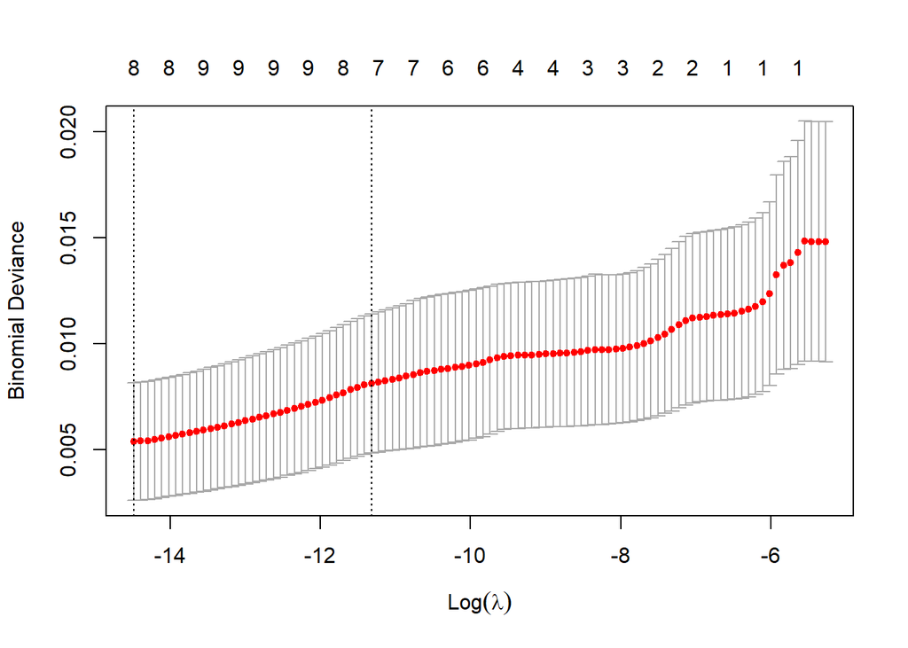

```r
set.seed(123)
cv.outL = cv.glmnet(x,y,family="binomial",alpha=1,nfolds=5)
plot(cv.outL)
```

```r
bestlambda = cv.outL$lambda.min
bestlambda
```

```
## [1] 5.124501e-07
```

```r
set.seed(123)
lasso.mod = glmnet(x,y,alpha=1, family="binomial", lambda=bestlambda, standardize=TRUE)
outL = glmnet(x,y,family="binomial",alpha=1)
coef(cv.outL,s=bestlambda)
```

```
## 13 x 1 sparse Matrix of class "dgCMatrix"
##                           s1
## (Intercept)    -1.215795e+01
## (Intercept)     .
## step           -7.276773e-03
## amount         -7.289448e-05
## oldbalanceOrg   8.310151e-05
## newbalanceOrig -1.703383e-04
## oldbalanceDest  6.991962e-08
## isFlaggedFraud  .
## type_payment   -3.993133e-02
## type_transfer   8.526996e+00
## type_cashin     .
## type_cashout    7.622889e+00
## type_debit      .
```

```r
# Predicciones con el modelo LASSO
realTestSinFraud <- realTest[,-7]
pred <- predict(lasso.mod, as.matrix(realTestSinFraud[,1:12]), type="link")
predResponse <- predict(lasso.mod, as.matrix(realTestSinFraud[,1:12]), type="response")
pred[1:10]
```

```
##  [1] 0 0 0 0 0 0 0 0 0 0
```

```r
predResponse[1:10]
```

```
##  [1] 0.5 0.5 0.5 0.5 0.5 0.5 0.5 0.5 0.5 0.5
```

```r
predicciones2 <- ifelse(predResponse > 0.20, yes = "predicted_TRUE", no = "predicted_FALSE")
matriz_confusión <- table(predicciones2, realTest$isFraud)
matriz_confusión
```

```
##
## predicciones2         0      1
##   predicted_TRUE 385663    373
```

No sé porque las valores de la predicción son todos los mismos. La predicción para la variable “predResponse” no tiene probabilidades pero soló valores de 0.5. Si tengo un Cutoff menor de 0.5, todos los preddiciones son True, que es muy malo. Hasta la seleción de variables todo es bueno. Por eso no puedo comparar los resultados de los dos modelos.

La ventaja del modelo Lasso es que es muy rápido. La desventaja es que las calculaciones son más dificiles de entender y las funciones en R para el modelo Lasso no son tan conocidos como las del modelo glm.